# ACTIVITY Summative 1

### Instructions

Please read carefully!

Write your code in the provided code chunks and answer any questions by typing outside the chunk.

Comment your code to let me know what you are trying to do, in case something doesn’t work.

Turn in a knitted rmd (html or pdf). If you can’t get your document to knit when you go to turn it in, just comment out the lines of code that are causing the knit to fail, knit the document, and submit.

## Problem 1

Load the tidyverse, lubridate, and dataRetrieval packages.

```r
#To laod packages
library(tidyverse)
library(lubridate)
library(dataRetrieval)
```

## Problem 2

Read in the McDonald Hollow dataset in the project folder.

What are the data types of the first three columns?

How long is the data (number of rows)?

What is the name of the last column?

**The data types are numeric data, the first column is the date-time, it shows both the date and time, the second column contains the turbidity unit in nephelometic and the third column is the total suspension solid measured in miligramsLitre

**The number of rows is 8831 with 12 columns

** Last column is TempC_pool

```r
#'McDonald_Hollow.csv' is your dataset file
McDonald_Hollow<- read_csv("McDonald_Hollow.csv")
# Get data types of the first three columns
data_types <- sapply(McDonald_Hollow[1:3, ], class)
head(data_types)
```

```
## $datetime
## [1] "POSIXct" "POSIXt"
##
## $turbidityNTU
## [1] "numeric"
##
## $TSSmgL
## [1] "numeric"
##
## $TDS_mgL
## [1] "numeric"
##
## $SpC_mScm
## [1] "numeric"
##
## $TempC_flow
## [1] "numeric"
```

```r
# Get the number of rows in the dataset
num_rows <- nrow(McDonald_Hollow)
head(num_rows)
```

```
## [1] 8831
```

```r
# Get the name of the last column
last_column <- names(McDonald_Hollow)[ncol(McDonald_Hollow)]
head(last_column)
```

```
## [1] "TempC_pool"
```

## Problem 3

Plot the stage of the stream (Stage_m_pt) on the y axis as a line and the date on the x. These stage data are in meters, convert them to centimeters for the plot.

For all plots in this test, label axes properly and use a theme other than the default.

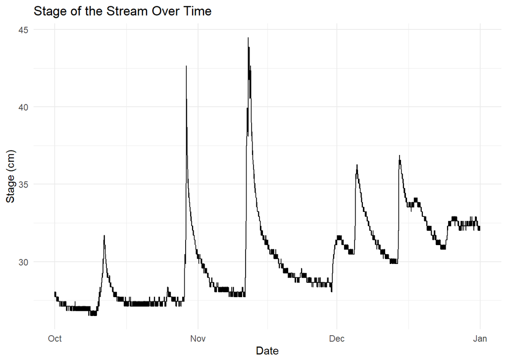

```r
# Convert units from meters to centimeters
McDonald_Hollow$Stage_cm_pt <- McDonald_Hollow$Stage_m_pt * 100

# Plotting the stage of the stream

ggplot(data = McDonald_Hollow, aes(x = datetime, y = Stage_cm_pt)) +
  geom_line() +
  labs(x = "Date", y = "Stage (cm)", title = "Stage of the Stream Over Time") +
  theme_minimal()  # You can use another theme if you prefer
```

## Problem 4

We want to look at the big event that happens from November 11, 2020 to November 27, 2020. Filter the dataset down to this time frame and save it separately. Make a plot with the same setup as in #3 with these newly saved data.

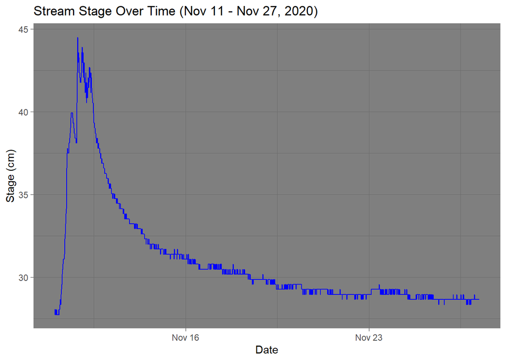

```r
# Convert the 'Stage_m_pt' column from meters to centimeters
McDonald_Hollow$Stage_cm_pt <- McDonald_Hollow$Stage_m_pt * 100

filtered_Mcdonald <- McDonald_Hollow %>%
  filter(datetime>=ymd("2020-11-11") & datetime <=("2020-11-27"))

# Plotting the filtered data
ggplot(data=filtered_Mcdonald, aes(x = datetime, y = Stage_cm_pt)) +
  geom_line(color = "blue") +
  labs(x = "Date", y = "Stage (cm)", title = "Stream Stage Over Time (Nov 11 - Nov 27, 2020)") +
  theme_dark()
```

## Problem 5

For this storm, we are curious about how conductivity changes with the stream level. To do this, make a scatter plot that shows Stage on the x axis and specific conductivity (SpC_mScm) on the y. (units: mScm) Color the points on the plot using the datetime column. Use the plot to describe how specific conductivity changes with stream stage throughout the storm. (not functionally, just how the values change)

**When the stream levels were low during the storm’s early phases, the specific conductivity increased and falls when the stream level is high. The specific conductivity increases as the stream stage drops during the storm’s later phases. Consequently, the graphic indicates that the specific conductivity and stream have a negative correlation. With decreasing specific conductivity, stream stage increases.

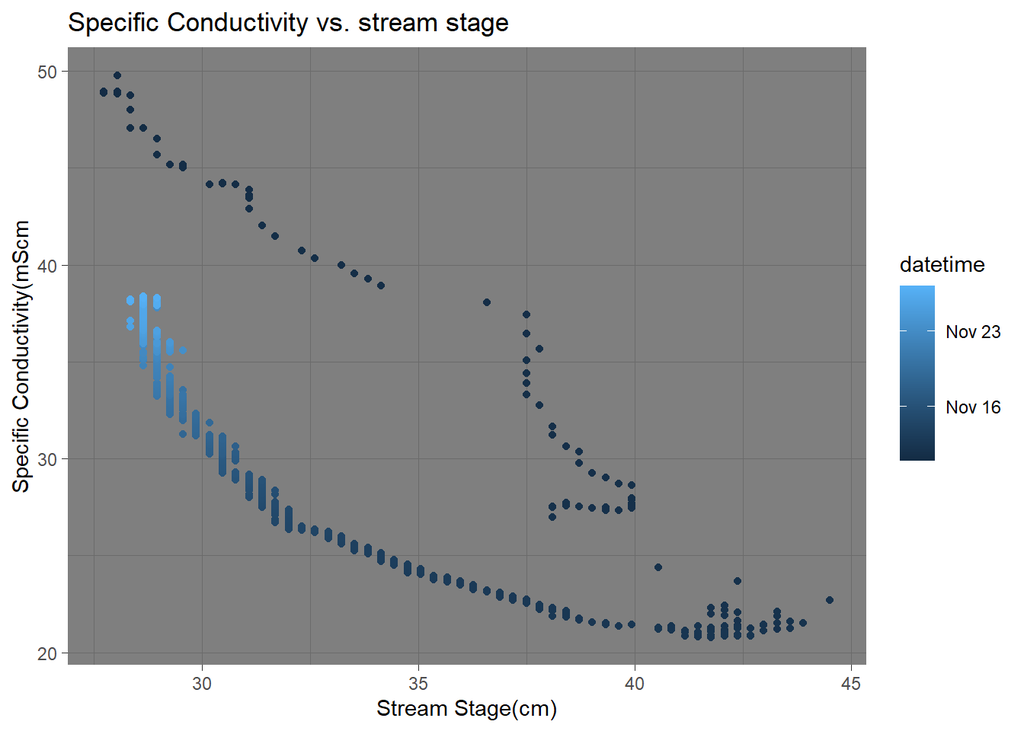

```r
ggplot(data=filtered_Mcdonald, aes(x= Stage_cm_pt,y =SpC_mScm, color=datetime))+
  geom_point()+
  xlab("Stream Stage(cm)")+
  ylab("Specific Conductivity(mScm")+
  labs(title = "Specific Conductivity vs. stream stage")+
  theme_dark()
```

## Problem 6

Continuing to look at the storm, as an exploratory data analysis, we want to create a plot that shows all the parameters measured. To do this, pivot the STORM EVENT data so there is a column that has the values for all the parameters measured as individual rows, along with another column that identifies the type of measurement. Then use facet_wrap with the “name” column (or whatever you call it) as the facet. Be sure to set the parameters of facet_wrap such that the y axes are all allowed to be different ranges.

EX:  
Date Value Name  
10/1/20 12 Stage  
10/1/20 6 Temp  
….

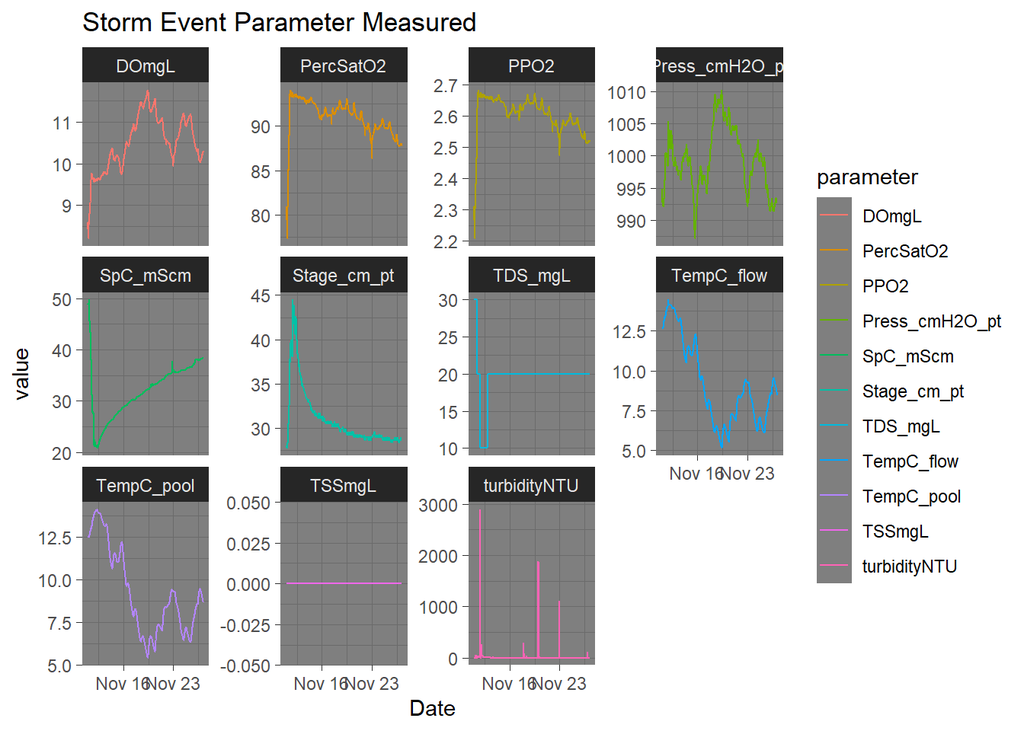

```r
pivoted_data <- filtered_Mcdonald%>%
pivot_longer(cols = -c(datetime, Stage_m_pt), names_to = "parameter", values_to = "value")

#Plotting the graph
ggplot(data=pivoted_data, aes(x = datetime, y= value, color= parameter))+
  geom_line()+
  facet_wrap(~parameter, scales = "free_y")+
  xlab("Date")+
  ylab("value")+
  labs(title= "Storm Event Parameter Measured")+
  theme_dark()
```

## Problem 7

We want to create a table that clearly shows the differences in water temperature for the three months at the two locations (flow and pool) in the FULL data set (not the storm subset). To do this: Create a new column in the full dataset called “month” and set it equal to the month of the datetime column using the month() function. Then group your dataset by month and summarize temperature at each location by mean. Save these results to a new object and output it so it appears below your chunk when you knit. Be sure the object has descriptive column names.

You can do this all in one statement using pipes.

```r
# Create a new column 'month' and calculate the mean temperature for each location and month
Monthlytemperature_summary <- McDonald_Hollow%>%
  mutate(month = month(datetime)) %>%
  group_by(month) %>%
  summarize(mean_temperature_pool = mean(TempC_pool, na.rm = TRUE),
            mean_temperature_flow = mean(TempC_flow, na.rm = TRUE))

# Output the summary table
Monthlytemperature_summary
```

```
## # A tibble: 3 × 3
##   month mean_temperature_pool mean_temperature_flow
##   <dbl>                 <dbl>                 <dbl>
## 1    10                 12.7                  12.6
## 2    11                  9.17                  9.08
## 3    12                  6.31                  6.19
```

## Problem 8

Plot the distribution of the flow temperature and show as vertical lines on the plot the mean, median, and IQR. Be careful about how you show IQR. Look at the definition and then think about how you would put it on the plot. Describe in the text above the chunk what color is what statistic in the plot. Using the shape of the distribution and the measures you plotted, explain why you think the distribution is normal or not. What statistical test could you perform to see if it is normal?

**One commonly used test is the Shapiro-Wilk test

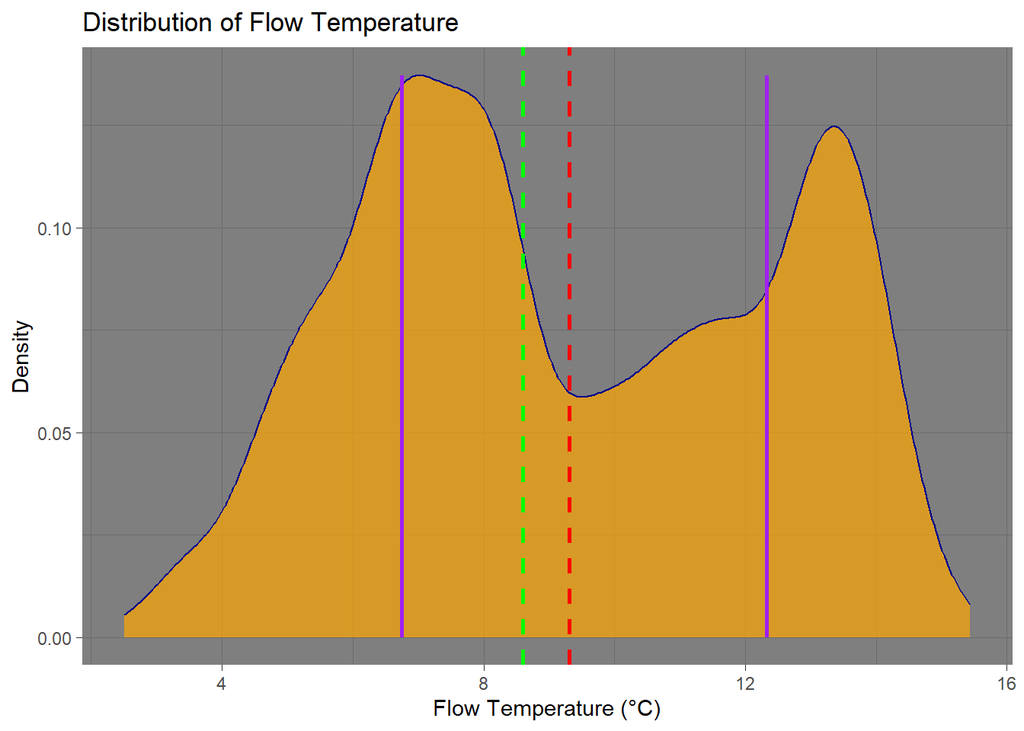

```r
# Plotting the distribution of flow temperature
ggplot(McDonald_Hollow, aes(x = TempC_flow)) +
  geom_density(fill = "orange", color = "darkblue", alpha = 0.7)+

  # Distribution plot
  geom_vline(aes(xintercept = mean(TempC_flow)), color = "red", linetype = "dashed", size = 1)+

  # Mean line
  geom_vline(aes(xintercept = median(TempC_flow)), color = "green", linetype = "dashed", size = 1)+

  # Median line
  geom_segment(aes(x = quantile(TempC_flow, 0.25), xend = quantile(TempC_flow, 0.25),
                   y = 0, yend = max(density(TempC_flow)$y)), color = "purple", size = 1)+

  # IQR segment
  geom_segment(aes(x = quantile(TempC_flow, 0.75), xend = quantile(TempC_flow, 0.75),
                   y = 0, yend = max(density(TempC_flow)$y)), color = "purple", size = 1) +

  # IQR segment
  labs(x = "Flow Temperature (°C)", y = "Density", title = "Distribution of Flow Temperature") +
  theme_dark()
```

```r
# Describe the color scheme:
# - Distribution: Filled orange with dark blue border.
# - Mean: Red dashed line.
# - Median: Green dashed line.
# - IQR: Purple segment with vertical lines indicating the lower and upper bounds.
```

## Problem 9

In this question we will get and format data for three USGS gages.

Gages: 03177710, 03173000, 03177480  
Discharge in cubic feet per second (cfs) code: 00060

1. Read and save the gage information for the three gages using readNWISsite().
2. Use the readNWISdv() function to read and save the daily discharge values for the following three gages for the 2020 water year (10-01-2019 to 9-30-2020). And then use the renameNWIScolumns() function to make the names human-friendly.
3. Join the gage site information from (a) to the data from (b) so you can reference the gages by their names.

```r
# a. Read and save gage information
gage_info <- readNWISsite(siteNumber = c("03177710", "03173000", "03177480"))

# b. Read and save daily discharge values for the 2020 water year
start_date <- "2019-10-01"
end_date <- "2020-09-30"
discharge_data <- readNWISdv(siteNumber = c("03177710", "03173000", "03177480"), parameterCd = "00060", startDate = start_date, endDate = end_date)%>%
  renameNWISColumns()

# c. Join gage site information to the discharge data
Joined_data <- left_join(gage_info, discharge_data, by = "site_no")

# Display the Joined data
head(Joined_data)
```

```
##   agency_cd.x  site_no               station_nm site_tp_cd lat_va long_va
## 1        USGS 03173000 WALKER CREEK AT BANE, VA         ST 371605  804235
## 2        USGS 03173000 WALKER CREEK AT BANE, VA         ST 371605  804235
## 3        USGS 03173000 WALKER CREEK AT BANE, VA         ST 371605  804235
## 4        USGS 03173000 WALKER CREEK AT BANE, VA         ST 371605  804235
## 5        USGS 03173000 WALKER CREEK AT BANE, VA         ST 371605  804235
## 6        USGS 03173000 WALKER CREEK AT BANE, VA         ST 371605  804235
##   dec_lat_va dec_long_va coord_meth_cd coord_acy_cd coord_datum_cd
## 1   37.26818   -80.70951             M            U          NAD27
## 2   37.26818   -80.70951             M            U          NAD27
## 3   37.26818   -80.70951             M            U          NAD27
## 4   37.26818   -80.70951             M            U          NAD27
## 5   37.26818   -80.70951             M            U          NAD27
## 6   37.26818   -80.70951             M            U          NAD27
##   dec_coord_datum_cd district_cd state_cd county_cd country_cd land_net_ds
```

[output cut: 41 more lines]

## Problem 10

Using the data from #9, Plot flow on the y axis and date on the x axis, showing the data as a line, and coloring by gage name.

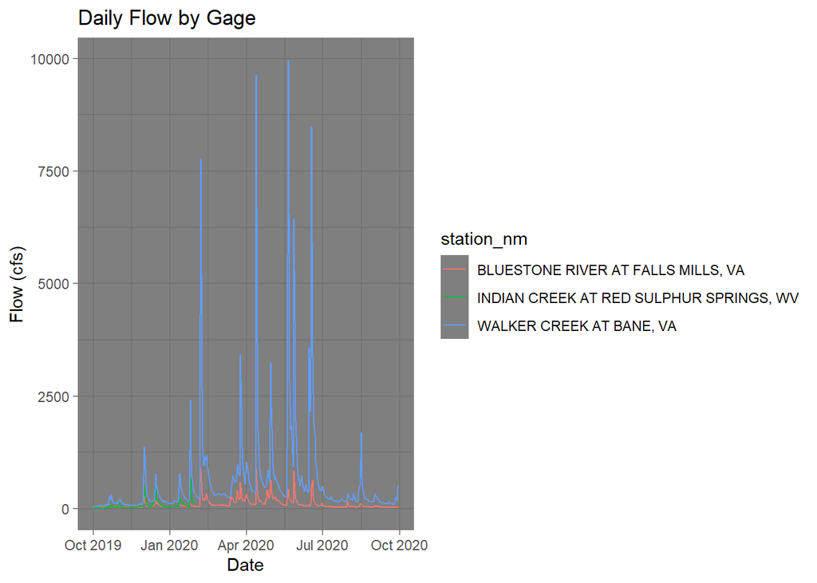

```r
# Plotting flow by date, colored by gage name
ggplot(Joined_data, aes(x = Date, y = Flow, color = station_nm)) +
  geom_line() +
  labs(x = "Date", y = "Flow (cfs)", title = "Daily Flow by Gage") +
  theme_dark()
```